# Calculating Biodiversity Indicators with msk

# Introduction

The `msk` package provides R functions for calculating biodiversity indicators from species occurrence data. It was developed for analysing data from the Swiss [Modular Stepwise Procedure](https://modul-stufen-konzept.ch/en/about-the-msp/) (Modulstufenkonzept, MSK), but works with any dataset following the [Darwin Core](https://dwc.tdwg.org/terms/) standard.

The typical workflow has four steps:

[interactive chart not shown]

This vignette is structured in four parts:

1. **Data structure** — the Darwin Core list format expected by `msk`
2. **Importing your own data** — converting a flat table with `as_msk()`
3. **Indicator functions** — how each function works, illustrated with macroinvertebrate data (`mzb`)
4. **Complete example** — a full analysis of Swiss NAWA fish monitoring data (`fisch`), including a custom biomass metric

```r
library(msk)
library(dplyr)
library(ggplot2)
library(patchwork)
```

# Data structure

The `msk` package expects data as a **list** with two data frames (tibbles), following the [Darwin Core](https://dwc.tdwg.org/terms/) standard.

**`event`** — one row per sampling event:

| Column | Description | Required |
| --- | --- | --- |
| `eventID` | Unique identifier for the event | yes |
| `eventDate` | Date of the sampling event | no |
| `locationID` | Identifier for the sampling location | no |

**`occurrence`** — one row per taxon observation:

| Column | Description | Required |
| --- | --- | --- |
| `eventID` | Link to the event table | yes |
| `taxonID` | Identifier for the recorded taxon | yes |
| `individualCount` | Number of individuals observed | no |

The two tables are linked by `eventID`. Additional columns (e.g. `year`, `altitude`, `scientificName`) can be added freely — they are preserved by all package functions.

## The `mzb` dataset

The package includes a macroinvertebrate dataset (`mzb`) from the Swiss NAWA monitoring programme, covering four campaigns (2012, 2015, 2019, 2023) across 85 stations below 1000 m a.s.l. that were sampled in all four campaigns:

```r
data("mzb")
str(mzb, max.level = 1)
```

```
#> List of 2
#>  $ event     : tibble [340 x 5] (S3: tbl_df/tbl/data.frame)
#>  $ occurrence: tibble [10,339 x 3] (S3: tbl_df/tbl/data.frame)
```

The **event** table has one row per sampling event:

```r
head(mzb$event)
```

```
#> # A tibble: 6 x 5
#>   eventID  eventDate  locationID  year altitude
#>   <chr>    <date>          <int> <int>    <dbl>
#> 1 100_2012 2012-03-21        100  2012      436
#> 2 100_2015 2015-02-25        100  2015      436
#> 3 100_2019 2019-02-25        100  2019      436
#> 4 100_2023 2023-03-01        100  2023      436
#> 5 101_2012 2012-03-21        101  2012      445
#> 6 101_2015 2015-02-25        101  2015      445
```

The **occurrence** table has one row per taxon per event:

```r
head(mzb$occurrence)
```

```
#> # A tibble: 6 x 3
#>   eventID taxonID          individualCount
#>   <chr>   <chr>                      <int>
#> 1 69_2012 Gyrinidae                      2
#> 2 69_2012 Hydracarina                   33
#> 3 69_2012 Lymnaeidae                     5
#> 4 69_2012 Taeniopterygidae               0
#> 5 69_2012 Taeniopterygidae               2
#> 6 69_2012 Nemouridae                     0
```

# Importing your own data

If your data is stored as a flat table — one row per taxon per sampling event — use `as_msk()` to convert it into the msk list format. The function works with any flat table; the default column names match the MIDAT flat export format.

## Workflow

Read the file into R with standard functions, then pipe directly into `as_msk()`. The package includes a MIDAT example file that you can use to try the workflow immediately:

```r
library(readxl)

path <- system.file("extdata", "midat_example.xlsx", package = "msk")
dat  <- read_excel(path) %>% as_msk()

dat$event
```

```
#> # A tibble: 3 x 6
#>   eventID         eventDate  locationID  year altitude locationName
#>   <chr>           <date>     <chr>      <int> <chr>    <chr>
#> 1 566195_20240703 2024-07-03 566195      2024 459      Ruisseau de Seyvaux
#> 2 596235_20240315 2024-03-15 596235      2024 563      Ruisseau de Neufs Champs
#> 3 608203_20240404 2024-04-04 608203      2024 606      Cholgrabe
```

For your own files, replace `system.file(...)` with the path to your export:

```r
# Excel
dat <- read_excel("midat_export.xlsx") %>% as_msk()

# CSV
dat <- read.csv("export.csv") %>% as_msk()
```

## Column mapping

Only the columns needed to identify events and taxa are required. Everything else is optional and controlled via two arguments:

- **`event_cols`**: extra columns added to the `event` table
- **`occurrence_cols`**: extra columns added to the `occurrence` table

Both accept a **named character vector** where the name becomes the output column name and the value is the source column in `dat`. Unnamed elements keep their original name. Columns not found in `dat` are silently skipped.

**Required columns** (with MIDAT defaults):

| Argument | MIDAT default | Description |
| --- | --- | --- |
| `location_id` | `"station_id"` | Sampling location identifier |
| `yyyy`, `mm`, `dd` | `"yyyy"`, `"mm"`, `"dd"` | Year / month / day |
| `date` | `NULL` | Alternative: single Date column |
| `taxon_id` | `"taxon_ibch"` | Taxon identifier |
| `count` | `"freq1"` | Individual count |
| `event_id` | `NULL` | Existing eventID column (optional) |

**Extra columns** default to MIDAT conventions:

```r
# Default: altitude and locationName included from MIDAT columns
as_msk(raw)

# No extra event columns
as_msk(raw, event_cols = NULL)

# Custom extra columns on both levels
as_msk(
  raw,
  event_cols      = c(altitude = "hohe", stream = "gewaesser"),
  occurrence_cols = c(spear = "spear_2019_11")
)
```

For a completely different export format, remap the required columns too:

```r
read_excel("other_export.xlsx") %>%
  as_msk(
    location_id     = "site_code",
    date            = "sample_date",
    taxon_id        = "species",
    count           = "n_individuals",
    event_cols      = c(altitude = "elevation", stream = "river_name"),
    occurrence_cols = c(RL = "red_list_status")
  )
```

## Worked example

The following toy dataset illustrates the conversion. The input is a flat table as it might come from a database export:

```r
flat <- data.frame(
  station_id = c(1, 1, 1, 2, 2),
  gewaesser  = c("Aare", "Aare", "Aare", "Thur", "Thur"),
  dd = 12, mm = 6, yyyy = 2023,
  hohe       = c(480, 480, 480, 395, 395),
  taxon_ibch = c("Baetidae", "Ephemerellidae", "Gammaridae",
                 "Baetidae", "Simuliidae"),
  freq1      = c(45, 12, 230, 18, 67),
  det_method = c("kick", "kick", "kick", "surber", "surber")
)

# MIDAT defaults: altitude and locationName added automatically
dat <- as_msk(flat)
dat$event
```

```
#> # A tibble: 2 x 6
#>   eventID    eventDate  locationID  year altitude locationName
#>   <chr>      <date>          <dbl> <int>    <dbl> <chr>
#> 1 1_20230612 2023-06-12          1  2023      480 Aare
#> 2 2_20230612 2023-06-12          2  2023      395 Thur
```

```r
dat$occurrence
```

```
#> # A tibble: 5 x 3
#>   eventID    taxonID        individualCount
#>   <chr>      <chr>                    <dbl>
#> 1 1_20230612 Baetidae                    45
#> 2 1_20230612 Ephemerellidae              12
#> 3 1_20230612 Gammaridae                 230
#> 4 2_20230612 Baetidae                    18
#> 5 2_20230612 Simuliidae                  67
```

Extra columns can be added to either table. Here we pass `det_method` to the occurrence table and skip `locationName`:

```r
as_msk(
  flat,
  event_cols      = c(altitude = "hohe"),
  occurrence_cols = c(method = "det_method")
)$occurrence
```

```
#> # A tibble: 5 x 4
#>   eventID    taxonID        individualCount method
#>   <chr>      <chr>                    <dbl> <chr>
#> 1 1_20230612 Baetidae                    45 kick
#> 2 1_20230612 Ephemerellidae              12 kick
#> 3 1_20230612 Gammaridae                 230 kick
#> 4 2_20230612 Baetidae                    18 surber
#> 5 2_20230612 Simuliidae                  67 surber
```

The result is immediately usable in indicator pipelines:

```r
as_msk(flat) %>%
  calc_alphadiv() %>%
  calc_abundance()
```

```
#> $event
#> # A tibble: 2 x 8
#>   eventID   eventDate  locationID  year altitude locationName alphadiv abundance
#>   <chr>     <date>          <dbl> <int>    <dbl> <chr>           <int>     <dbl>
#> 1 1_202306~ 2023-06-12          1  2023      480 Aare                3       287
#> 2 2_202306~ 2023-06-12          2  2023      395 Thur                2        85
#>
#> $occurrence
#> # A tibble: 5 x 3
#>   eventID    taxonID        individualCount
#>   <chr>      <chr>                    <dbl>
#> 1 1_20230612 Baetidae                    45
#> 2 1_20230612 Ephemerellidae              12
#> 3 1_20230612 Gammaridae                 230
#> 4 2_20230612 Baetidae                    18
#> 5 2_20230612 Simuliidae                  67
```

# Indicator functions

The `msk` package provides two types of indicator functions:

- **Event-level functions** add a new column to the `event` table and return the modified data list. They are chainable with `%>%`.
- **Group-level functions** compute indicators across sets of events and return a separate summary tibble.

## Alpha diversity

Alpha diversity is the number of distinct taxa per sampling event. `calc_alphadiv()` adds an `alphadiv` column to the event table:

```r
dat <- mzb %>%
  calc_alphadiv()

head(dat$event)
```

```
#> # A tibble: 6 x 6
#>   eventID  eventDate  locationID  year altitude alphadiv
#>   <chr>    <date>          <int> <int>    <dbl>    <int>
#> 1 100_2012 2012-03-21        100  2012      436       12
#> 2 100_2015 2015-02-25        100  2015      436       19
#> 3 100_2019 2019-02-25        100  2019      436       28
#> 4 100_2023 2023-03-01        100  2023      436       29
#> 5 101_2012 2012-03-21        101  2012      445       10
#> 6 101_2015 2015-02-25        101  2015      445       12
```

## Abundance

`calc_abundance()` supports two methods, selected with the `method` argument:

- **`"total"`** (default): sum of `individualCount` per event. Reflects overall abundance but is sensitive to dominant taxa.
- **`"mean_per_taxon"`**: mean of per-taxon counts per event. Less sensitive to dominant taxa; useful for tracking whether individual species become more or less abundant on average across taxa of different commonness.

Both methods can be applied in sequence:

```r
dat <- dat %>%
  calc_abundance(method = "total") %>%
  calc_abundance(method = "mean_per_taxon")

head(dat$event)
```

```
#> # A tibble: 6 x 8
#>   eventID eventDate  locationID  year altitude alphadiv abundance abundance_mean
#>   <chr>   <date>          <int> <int>    <dbl>    <int>     <int>          <dbl>
#> 1 100_20~ 2012-03-21        100  2012      436       12       406           33.8
#> 2 100_20~ 2015-02-25        100  2015      436       19      1122           59.1
#> 3 100_20~ 2019-02-25        100  2019      436       28      1681           60.0
#> 4 100_20~ 2023-03-01        100  2023      436       29      1466           50.6
#> 5 101_20~ 2012-03-21        101  2012      445       10       388           38.8
#> 6 101_20~ 2015-02-25        101  2015      445       12       385           32.1
```

The result columns are named `abundance` (total) and `abundance_mean` (mean per taxon).

## Gamma diversity

Gamma diversity is the total number of distinct taxa across a group of events. Unlike alpha diversity, this is a group-level metric, so `calc_gammadiv()` returns a summary tibble. Use `group_by_col` to compute it separately per year:

```r
calc_gammadiv(mzb, group_by_col = "year")
```

```
#> # A tibble: 4 x 2
#>    year gammadiv
#>   <int>    <int>
#> 1  2012       81
#> 2  2015       84
#> 3  2019       82
#> 4  2023       83
```

## Beta diversity

Beta diversity measures how different communities are between events. `calc_betadiv()` computes pairwise **Simpson dissimilarity**:

$$\beta_{sim} = \frac{\min(b, c)}{a +
\min(b, c)}$$

where *a* = shared taxa, *b* and *c* = taxa unique to each event. The index ranges from 0 (identical communities) to 1 (no shared taxa) and is independent of richness differences.

```r
calc_betadiv(mzb, group_by_col = "year")
```

```
#> # A tibble: 4 x 4
#>    year betadiv_mean betadiv_q25 betadiv_q75
#>   <int>        <dbl>       <dbl>       <dbl>
#> 1  2012        0.329       0.222       0.429
#> 2  2015        0.293       0.2         0.379
#> 3  2019        0.308       0.219       0.389
#> 4  2023        0.295       0.207       0.370
```

The output contains the mean and the 25th/75th percentile of pairwise dissimilarities within each group.

# Chaining and visualisation

Event-level functions return the data list unchanged (except for the new column), so they compose naturally. The following pipeline computes alpha diversity and abundance for `mzb` in a single chain:

```r
campaigns <- c(2012, 2015, 2019, 2023)

mzb_ind <- mzb %>%
  calc_alphadiv() %>%
  calc_abundance(method = "total")

alpha_mzb <- mzb_ind$event %>%
  group_by(year) %>%
  summarise(
    mean = mean(alphadiv),
    lo   = mean - qt(0.975, n() - 1) * sd(alphadiv) / sqrt(n()),
    up   = mean + qt(0.975, n() - 1) * sd(alphadiv) / sqrt(n()),
    .groups = "drop"
  )

abund_mzb <- mzb_ind$event %>%
  group_by(year) %>%
  summarise(
    mean = mean(abundance),
    lo   = mean - qt(0.975, n() - 1) * sd(abundance) / sqrt(n()),
    up   = mean + qt(0.975, n() - 1) * sd(abundance) / sqrt(n()),
    .groups = "drop"
  )

beta_mzb <- calc_betadiv(mzb, group_by_col = "year")
```

All indicator outputs are standard tibbles and work directly with `ggplot2`:

[output not shown]

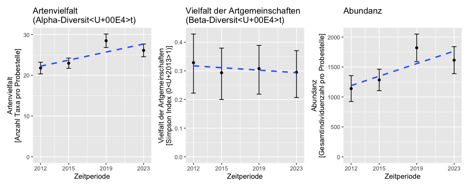

```r
p_alpha <- ggplot(alpha_mzb, aes(x = year, y = mean, ymin = lo, ymax = up)) +
  geom_point() +
  geom_errorbar(width = 0.5) +
  geom_smooth(method = "lm", se = FALSE, linetype = 2) +
  scale_x_continuous(breaks = campaigns) +
  ylim(0, NA) +
  labs(
    title = "Artenvielfalt\n(Alpha-Diversität)",
    x     = "Zeitperiode",
    y     = "Artenvielfalt\n[Anzahl Taxa pro Probestelle]"
  )

p_beta <- ggplot(beta_mzb, aes(x = year, y = betadiv_mean,
                                ymin = betadiv_q25, ymax = betadiv_q75)) +
  geom_point() +
  geom_errorbar(width = 0.5) +
  geom_smooth(method = "lm", se = FALSE, linetype = 2) +
  scale_x_continuous(breaks = campaigns) +
  ylim(0, NA) +
  labs(
    title = "Vielfalt der Artgemeinschaften\n(Beta-Diversität)",
    x     = "Zeitperiode",
    y     = "Vielfalt der Artgemeinschaften\n[Simpson Index (0–1)]"
  )

p_abund <- ggplot(abund_mzb, aes(x = year, y = mean, ymin = lo, ymax = up)) +
  geom_point() +
  geom_errorbar(width = 0.5) +
  geom_smooth(method = "lm", se = FALSE, linetype = 2) +
  scale_x_continuous(breaks = campaigns) +
  ylim(0, NA) +
  labs(
    title = "Abundanz",
    x     = "Zeitperiode",
    y     = "Abundanz\n[Gesamtindividuenzahl pro Probestelle]"
  )

p_alpha + p_beta + p_abund
```

# Index normalisation

To express indicators relative to a reference point (base = 100), use `calc_indicator_index()`. This is useful for comparing trends across indicators or datasets measured on different scales.

Here we normalise gamma diversity relative to the 2012 baseline:

```r
gamma_mzb <- calc_gammadiv(mzb, group_by_col = "year")

gamma_indexed <- calc_indicator_index(
  gamma_mzb,
  value_col = "gammadiv",
  group_col = "year",
  ref_value = 2012
)
gamma_indexed
```

```
#> # A tibble: 4 x 3
#>    year gammadiv index
#>   <int>    <int> <dbl>
#> 1  2012       81  100
#> 2  2015       84  104.
#> 3  2019       82  101.
#> 4  2023       83  102.
```

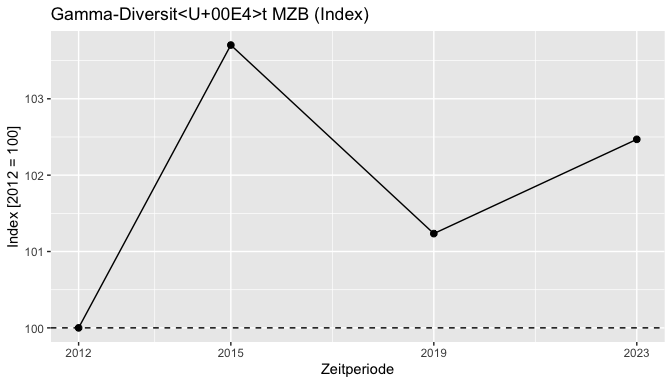

```r
ggplot(gamma_indexed, aes(x = year, y = index)) +
  geom_hline(yintercept = 100, linetype = 2) +
  geom_point(size = 2) +
  geom_line() +
  scale_x_continuous(breaks = campaigns) +
  labs(
    title = "Gamma-Diversität MZB (Index)",
    x     = "Zeitperiode",
    y     = "Index [2012 = 100]"
  )
```

# Complete example: Fish data

The `fisch` dataset contains NAWA fish monitoring data from four campaigns (2012, 2015, 2019, 2023) across 51 stations sampled in at least three of the four campaigns. It demonstrates how the Darwin Core structure accommodates additional variables: the `totalWeight_g` column in the occurrence table enables biomass analyses alongside the standard diversity indicators.

## Data overview

```r
data("fisch")
str(fisch, max.level = 1)
```

```
#> List of 2
#>  $ event     : tibble [176 x 6] (S3: tbl_df/tbl/data.frame)
#>  $ occurrence: tibble [1,109 x 6] (S3: tbl_df/tbl/data.frame)
```

The event table contains metadata including the number of electrofishing runs (`N_runs`) and the stream name:

```r
head(fisch$event)
```

```
#> # A tibble: 6 x 6
#>   eventID              locationID  year altitude stream  N_runs
#>   <chr>                     <int> <int>    <dbl> <chr>    <int>
#> 1 CH_002_BS_FISH-41134          2  2012     248. Birs         3
#> 2 CH_002_BS_FISH-42271          2  2015     248. Birs         3
#> 3 CH_002_BS_FISH-43734          2  2019     248. Birs         4
#> 4 CH_009_SO_FISH-42271          9  2015     461. Limpach      1
#> 5 CH_009_SO_FISH-43721          9  2019     461. Limpach      1
#> 6 CH_009_SO_FISH-45148          9  2023     461. Limpach      1
```

The occurrence table contains one row per species per event, with abundance (individuals), biomass, and species names:

```r
head(fisch$occurrence)
```

```
#> # A tibble: 6 x 6
#>   eventID    taxonID individualCount totalWeight_g scientificName vernacularName
#>   <chr>        <dbl>           <int>         <dbl> <chr>          <chr>
#> 1 CH_002_BS~   70001               1           2   Lampetra plan~ Bachneunauge
#> 2 CH_002_BS~   70003               4        2666   Anguilla angu~ Aal
#> 3 CH_002_BS~   70012              10          49   Salmo trutta ~ Atlantische F~
#> 4 CH_002_BS~   70022              17        4716   Thymallus thy~ Aesche
#> 5 CH_002_BS~   70030               1        1875   Cyprinus carp~ Karpfen
#> 6 CH_002_BS~   70032               9          27.4 Alburnoides b~ Schneider
```

## Calculating indicators

We use the standard `msk` functions for alpha diversity and abundance, then add a custom biomass metric derived directly from the occurrence table. This illustrates how the Darwin Core structure makes it straightforward to extend the standard workflow with dataset-specific metrics:

```r
fisch_ind <- fisch %>%
  calc_alphadiv() %>%
  calc_abundance(method = "total")

# Custom metric: total biomass per event (sum of totalWeight_g)
biomass_per_event <- fisch$occurrence %>%
  group_by(eventID) %>%
  summarise(biomass_g = sum(totalWeight_g, na.rm = TRUE), .groups = "drop")

fisch_ind$event <- fisch_ind$event %>%
  left_join(biomass_per_event, by = "eventID")

head(fisch_ind$event)
```

```
#> # A tibble: 6 x 9
#>   eventID   locationID  year altitude stream N_runs alphadiv abundance biomass_g
#>   <chr>          <int> <int>    <dbl> <chr>   <int>    <int>     <int>     <dbl>
#> 1 CH_002_B~          2  2012     248. Birs        3       15      1230   100312.
#> 2 CH_002_B~          2  2015     248. Birs        3       13      8958    18894.
#> 3 CH_002_B~          2  2019     248. Birs        4       13      4128    11029
#> 4 CH_009_S~          9  2015     461. Limpa~      1        7      1592     2434
#> 5 CH_009_S~          9  2019     461. Limpa~      1        9      1415    16601
#> 6 CH_009_S~          9  2023     461. Limpa~      1        6       358     5407
```

## Summarising by year

```r
campaigns <- c(2012, 2015, 2019, 2023)

alpha_fisch <- fisch_ind$event %>%
  group_by(year) %>%
  summarise(
    mean = mean(alphadiv),
    lo   = mean - qt(0.975, n() - 1) * sd(alphadiv) / sqrt(n()),
    up   = mean + qt(0.975, n() - 1) * sd(alphadiv) / sqrt(n()),
    .groups = "drop"
  )

abund_fisch <- fisch_ind$event %>%
  group_by(year) %>%
  summarise(
    mean = mean(abundance),
    lo   = mean - qt(0.975, n() - 1) * sd(abundance) / sqrt(n()),
    up   = mean + qt(0.975, n() - 1) * sd(abundance) / sqrt(n()),
    .groups = "drop"
  )

biomass_fisch <- fisch_ind$event %>%
  group_by(year) %>%
  summarise(
    mean = mean(biomass_g),
    lo   = mean - qt(0.975, n() - 1) * sd(biomass_g) / sqrt(n()),
    up   = mean + qt(0.975, n() - 1) * sd(biomass_g) / sqrt(n()),
    .groups = "drop"
  )

beta_fisch  <- calc_betadiv(fisch, group_by_col = "year")
gamma_fisch <- calc_gammadiv(fisch, group_by_col = "year")
```

## Results

[output not shown]

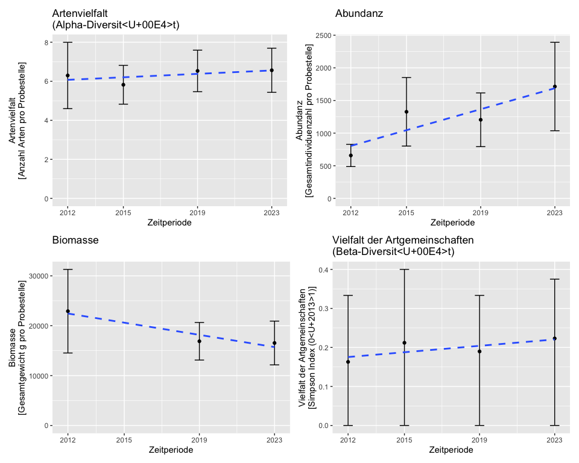

```r
p_alpha_f <- ggplot(alpha_fisch, aes(x = year, y = mean, ymin = lo, ymax = up)) +
  geom_point() +
  geom_errorbar(width = 0.5) +
  geom_smooth(method = "lm", se = FALSE, linetype = 2) +
  scale_x_continuous(breaks = campaigns) +
  ylim(0, NA) +
  labs(
    title = "Artenvielfalt\n(Alpha-Diversität)",
    x     = "Zeitperiode",
    y     = "Artenvielfalt\n[Anzahl Arten pro Probestelle]"
  )

p_abund_f <- ggplot(abund_fisch, aes(x = year, y = mean, ymin = lo, ymax = up)) +
  geom_point() +
  geom_errorbar(width = 0.5) +
  geom_smooth(method = "lm", se = FALSE, linetype = 2) +
  scale_x_continuous(breaks = campaigns) +
  ylim(0, NA) +
  labs(
    title = "Abundanz",
    x     = "Zeitperiode",
    y     = "Abundanz\n[Gesamtindividuenzahl pro Probestelle]"
  )

p_biomass_f <- ggplot(biomass_fisch, aes(x = year, y = mean, ymin = lo, ymax = up)) +
  geom_point() +
  geom_errorbar(width = 0.5) +
  geom_smooth(method = "lm", se = FALSE, linetype = 2) +
  scale_x_continuous(breaks = campaigns) +
  ylim(0, NA) +
  labs(
    title = "Biomasse",
    x     = "Zeitperiode",
    y     = "Biomasse\n[Gesamtgewicht g pro Probestelle]"
  )

p_beta_f <- ggplot(beta_fisch, aes(x = year, y = betadiv_mean,
                                    ymin = betadiv_q25, ymax = betadiv_q75)) +
  geom_point() +
  geom_errorbar(width = 0.5) +
  geom_smooth(method = "lm", se = FALSE, linetype = 2) +
  scale_x_continuous(breaks = campaigns) +
  ylim(0, NA) +
  labs(
    title = "Vielfalt der Artgemeinschaften\n(Beta-Diversität)",
    x     = "Zeitperiode",
    y     = "Vielfalt der Artgemeinschaften\n[Simpson Index (0–1)]"
  )

(p_alpha_f + p_abund_f) / (p_biomass_f + p_beta_f)
```

Gamma diversity shows the total number of fish species recorded across all stations per campaign:

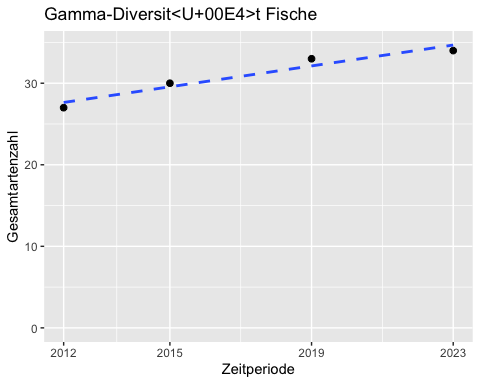

```r
ggplot(gamma_fisch, aes(x = year, y = gammadiv)) +
  geom_point(size = 2) +
  geom_smooth(method = "lm", se = FALSE, linetype = 2) +
  scale_x_continuous(breaks = campaigns) +
  ylim(0, NA) +
  labs(
    title = "Gamma-Diversität Fische",
    x     = "Zeitperiode",
    y     = "Gesamtartenzahl"
  )
```